# Descriptive analysis of text

Pablo Barbera

May 19, 2016

In this module we will discuss some quick descriptive statistics of text datasets. We’ll be working with the dataset of inaugural speeches of U.S. Presidents

```r
library(quanteda)
tf <- textfile(file='../datasets/inaugTexts.csv', textField = 'inaugSpeech')
inaug <- corpus(tf)
#docnames(inaug) <- paste(inaug[['President']], inaug[["Year"]], sep=":")
```

The simplest of these is through the `summary()` method:

```r
summary(inaug)
```

```
## Corpus consisting of 57 documents.
##
##    Text Types Tokens Sentences Year  President
##   text1   626   1540        24 1789 Washington
##   text2    96    147         4 1793 Washington
##   text3   826   2584        37 1797      Adams
##   text4   716   1935        42 1801  Jefferson
##   text5   804   2381        45 1805  Jefferson
##   text6   536   1267        21 1809    Madison
##   text7   542   1304        33 1813    Madison
##   text8  1040   3696       121 1817     Monroe
##   text9  1262   4898       131 1821     Monroe
##  text10  1004   3154        74 1825      Adams
##  text11   517   1210        25 1829    Jackson
##  text12   499   1271        30 1833    Jackson
##  text13  1315   4175        95 1837   VanBuren
##  text14  1893   9178       210 1841   Harrison
##  text15  1330   5211       153 1845       Polk
##  text16   497   1185        22 1849     Taylor
##  text17  1166   3657       104 1853     Pierce
##  text18   945   3106        89 1857   Buchanan
##  text19  1075   4016       138 1861    Lincoln
##  text20   362    780        27 1865    Lincoln
##  text21   486   1243        41 1869      Grant
##  text22   552   1479        44 1873      Grant
##  text23   829   2730        59 1877      Hayes
##  text24  1018   3240       112 1881   Garfield
##  text25   674   1828        44 1885  Cleveland
##  text26  1355   4744       157 1889   Harrison
##  text27   823   2135        58 1893  Cleveland
##  text28  1236   4383       130 1897   McKinley
##  text29   857   2449       100 1901   McKinley
##  text30   404   1089        33 1905  Roosevelt
##  text31  1436   5844       159 1909       Taft
##  text32   661   1896        68 1913     Wilson
##  text33   549   1656        60 1917     Wilson
##  text34  1172   3743       149 1921    Harding
##  text35  1221   4442       197 1925   Coolidge
##  text36  1086   3895       171 1929     Hoover
##  text37   744   2064        85 1933  Roosevelt
```

[output cut: 9 more lines]

```
##  text47   545   2018        69 1973      Nixon
##  text48   528   1380        53 1977     Carter
##  text49   904   2798       128 1981     Reagan
##  text50   925   2935       125 1985     Reagan
##  text51   795   2683       143 1989       Bush
##  text52   644   1837        81 1993    Clinton
##  text53   773   2451       112 1997    Clinton
##  text54   622   1810        97 2001       Bush
##  text55   772   2325       101 2005       Bush
##  text56   939   2729       112 2009      Obama
##  text57   814   2335        90 2013      Obama
##
## Source:  /Users/pablobarbera/git/eui-text-workshop/01-intro/* on x86_64 by pablobarbera
## Created: Wed May 18 18:01:46 2016
## Notes:
```

We have already seen how to look at the most common features:

```r
presDfm <- dfm(inaugCorpus, ignoredFeatures = stopwords("english"), ngrams=c(1,3))
```

```
## Creating a dfm from a corpus ...
##    ... lowercasing
##    ... tokenizing
##    ... indexing documents: 57 documents
##    ... indexing features: 121,855 feature types
##    ... removed 106,489 features, from 174 supplied (glob) feature types
##    ... created a 57 x 15366 sparse dfm
##    ... complete.
## Elapsed time: 3.361 seconds.
```

```r
topfeatures(presDfm)
```

```
##       will     people government         us        can       upon
##        871        565        561        476        470        371
##       must        may      great     states
##        363        338        334        331
```

Other basic statistics of any dataset:

```r
# number of documents
ndoc(inaug)
```

```
## [1] 57
```

```r
# number of tokens (total words)
ntoken(inaug)
```

```
##  text1  text2  text3  text4  text5  text6  text7  text8  text9 text10
##   1540    147   2584   1935   2381   1267   1304   3696   4898   3154
## text11 text12 text13 text14 text15 text16 text17 text18 text19 text20
##   1210   1271   4175   9178   5211   1185   3657   3106   4016    780
## text21 text22 text23 text24 text25 text26 text27 text28 text29 text30
##   1243   1479   2730   3240   1828   4744   2135   4383   2449   1089
## text31 text32 text33 text34 text35 text36 text37 text38 text39 text40
##   5844   1896   1656   3743   4442   3895   2064   2027   1552    651
## text41 text42 text43 text44 text45 text46 text47 text48 text49 text50
##   2531   2765   1933   1568   1725   2437   2018   1380   2798   2935
## text51 text52 text53 text54 text55 text56 text57
##   2683   1837   2451   1810   2325   2729   2335
```

```r
# number of types (unique words)
ntype(inaug)
```

```
##  text1  text2  text3  text4  text5  text6  text7  text8  text9 text10
##    626     96    826    716    804    536    542   1040   1262   1004
## text11 text12 text13 text14 text15 text16 text17 text18 text19 text20
##    517    499   1315   1893   1330    497   1166    945   1075    362
## text21 text22 text23 text24 text25 text26 text27 text28 text29 text30
##    486    552    829   1018    674   1355    823   1236    857    404
## text31 text32 text33 text34 text35 text36 text37 text38 text39 text40
##   1436    661    549   1172   1221   1086    744    729    527    276
## text41 text42 text43 text44 text45 text46 text47 text48 text49 text50
##    781    903    621    566    569    743    545    528    904    925
## text51 text52 text53 text54 text55 text56 text57
##    795    644    773    622    772    939    814
```

```r
# number of documents and features in DFM
ndoc(presDfm)
```

```
## [1] 57
```

```r
nfeature(presDfm)
```

```
## [1] 15366
```

```r
# extract feature labels and document names
head(features(presDfm), 20)
```

```
##  [1] "fellow-citizens" "senate"          "house"
##  [4] "representatives" "among"           "vicissitudes"
##  [7] "incident"        "life"            "event"
## [10] "filled"          "greater"         "anxieties"
## [13] "notification"    "transmitted"     "order"
## [16] "received"        "14th"            "day"
## [19] "present"         "month"
```

```r
head(docnames(presDfm))
```

```
## [1] "1789-Washington" "1793-Washington" "1797-Adams"      "1801-Jefferson"
## [5] "1805-Jefferson"  "1809-Madison"
```

A common type of analysis to understand the content of a corpus is to extract collocations – combinations of words that are more likely to appear together than what is expected based on their frequency distribution in the corpus as isolated words. There are different significante tests to identify whether a combination of words is a collocation or not (see the help file).

```r
collocations(inaug, size = 2, method = "all")
```

```
##          word1  word2 word3 count           G2           X2           pmi
##     1:      of    the        1763 2.277697e+03 3.400285e+03  1.2198506555
##     2:  united states         155 1.718445e+03 4.482535e+04  5.6696522405
##     3:      it     is         317 1.544799e+03 6.869994e+03  3.1428222402
##     4:    have   been         201 1.319884e+03 9.862703e+03  3.9209525753
##     5:     has   been         179 1.316934e+03 1.289645e+04  4.2956897902
##    ---
## 55236:    need    our           1 2.420774e-04 6.165938e-07  0.0007788743
## 55237:    duty     in           2 2.419981e-04 5.379514e-07 -0.0005133938
## 55238:      to   back           1 2.417511e-04 2.917205e-07 -0.0005299505
## 55239:      to   vast           1 2.417511e-04 2.917205e-07 -0.0005299505
## 55240: subject     in           1 2.417288e-04 2.688598e-07 -0.0005133938
##                dice
##     1: 0.2208442941
##     2: 0.5893536122
##     3: 0.2463092463
##     4: 0.2716216216
##     5: 0.3275388838
##    ---
## 55236: 0.0010261673
## 55237: 0.0016481253
## 55238: 0.0004443457
## 55239: 0.0004443457
## 55240: 0.0008421053
```

```r
collocations(inaug, size = 3, method = "all")
```

```
##        word1        word2 word3 count          G2           X2       pmi
##     1:   the constitution    of    22 8365.894944   2964177.97 14.902111
##     2:   the       people    of    43 8331.190031  14162186.39 16.466086
##     3:   the        world    of     3 8269.279425    479014.54 13.079488
##     4:   the       spirit    of    24 8185.344405 162865151.31 18.908433
##     5:   the    executive    of     1 8171.543329   7864785.48 15.877897
##    ---
## 89124:    in          new   and     1    2.810693   2934668.04 14.892050
## 89125:   and        peace    of     1    2.399323   1338616.08 14.107148
## 89126:   and           to  such     1    2.342775  27919738.75 17.144845
## 89127:   and           to which     1    2.184186     10541.42  9.263198
## 89128:   and           to  this     1    1.505681    225755.76 12.327216
##                dice
##     1: 0.0020120724
##     2: 0.0094339623
##     3: 0.0003265306
##     4: 0.0869565217
##     5: 0.0215053763
##    ---
## 89124: 0.0058651026
## 89125: 0.0066006601
## 89126: 0.0869565217
## 89127: 0.0005107252
## 89128: 0.0024875622
```

```r
tweets <- read.csv("../datasets/EP-elections-tweets.csv", stringsAsFactors=F)
twcorpus <- corpus(tweets$text)
collocations(twcorpus, size = 2, method = "all")
```

```
##                 word1  word2 word3 count           G2           X2
##     1:          thank    you         220 1.763705e+03 1.309885e+04
##     2:           good   luck         120 1.245671e+03 2.882025e+04
##     3:           well   done          98 1.051865e+03 3.022213e+04
##     4:           many thanks         116 9.361934e+02 1.189751e+04
##     5:           will     be         143 8.575508e+02 5.803401e+03
##    ---
## 57104:             me     my           1 2.511876e-04 3.159697e-06
## 57105:             in tories           1 2.491940e-04 1.167464e-06
## 57106:             be     up           2 2.489522e-04 9.262529e-07
## 57107: @tasminasheikh    and           1 2.488971e-04 8.718610e-07
## 57108:  @nigel_farage better           1 2.481595e-04 1.332393e-07
##                  pmi        dice
##     1:  4.1022618369 0.201465201
##     2:  5.4852699644 0.441988950
##     3:  5.7345688204 0.483950617
##     4:  4.6433912580 0.290726817
##     5:  3.7407278415 0.216666667
##    ---
## 57104: -0.0017723788 0.002770083
## 57105: -0.0010718590 0.001012658
## 57106:  0.0006775560 0.003686636
## 57107:  0.0009277224 0.001255493
## 57108: -0.0003627877 0.001321877
```

A text document can also be characterized based on its readability and lexical diversity, which capture different aspects of its complexity. There are MANY indices that compute this. Note that each of these functions is applied to a different type of object (`corpus` or `dfm`).

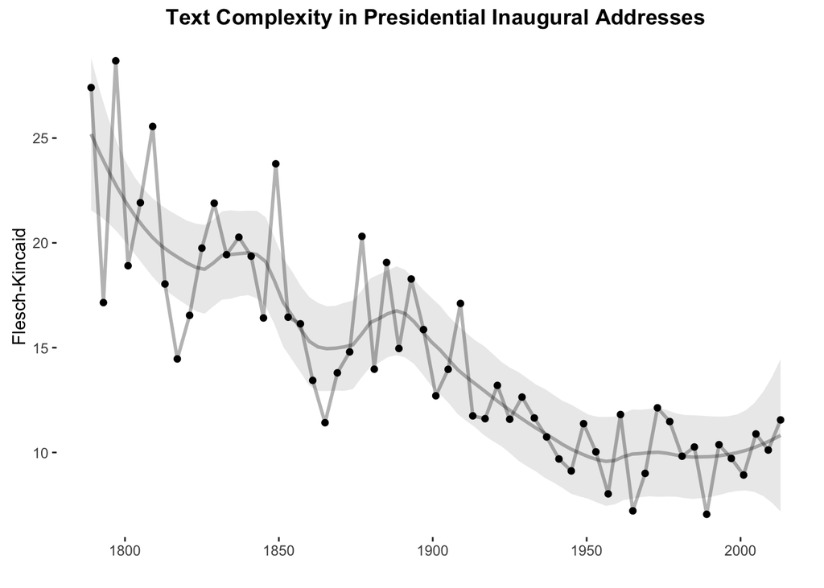

```r
# readability
fk <- readability(inaug, "Flesch.Kincaid")
# lexical diversity
ld <- lexdiv(presDfm)

# plot readability over time
require(ggplot2)
p <- ggplot(data = docvars(inaug), aes(x = Year, y = fk)) +
    theme(panel.grid.major = element_blank(),
          panel.grid.minor = element_blank(),
          panel.background = element_blank(),
          axis.line = element_line(colour = "black")) +
    geom_smooth(alpha=0.2, linetype=1, color="grey70", method = "loess", span = .34) +
    xlab("") +
    ylab("Flesch-Kincaid") +
    geom_point() +
    geom_line(alpha=0.3, size = 1) +
    ggtitle("Text Complexity in Presidential Inaugural Addresses") +
    theme(plot.title = element_text(lineheight=.8, face="bold"))
quartz(height=7, width=12)
print(p)
```

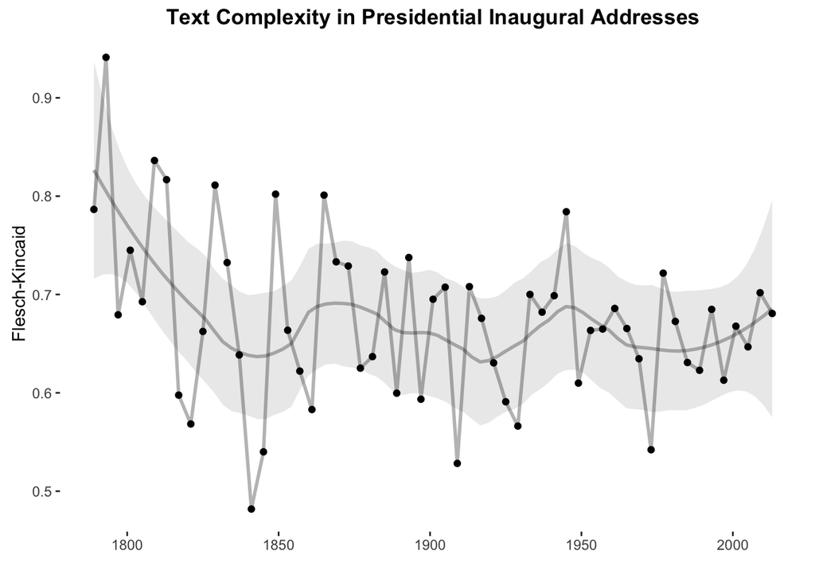

```r
# plot lexical diversity over time
require(ggplot2)
p <- ggplot(data = docvars(inaug), aes(x = Year, y = ld)) +
    theme(panel.grid.major = element_blank(),
          panel.grid.minor = element_blank(),
          panel.background = element_blank(),
          axis.line = element_line(colour = "black")) +
    geom_smooth(alpha=0.2, linetype=1, color="grey70", method = "loess", span = .34) +
    xlab("") +
    ylab("Flesch-Kincaid") +
    geom_point() +
    geom_line(alpha=0.3, size = 1) +
    ggtitle("Text Complexity in Presidential Inaugural Addresses") +
    theme(plot.title = element_text(lineheight=.8, face="bold"))
quartz(height=7, width=12)
print(p)
```

We can identify documents that are similar to one another based on the frequency of words, using `similarity`:

```r
# document similarities
similarity(presDfm, "1985-Reagan", n=5, margin="documents")
```

```
## similarity Matrix:
## $`1985-Reagan`
##  1981-Reagan 1997-Clinton   2013-Obama   1973-Nixon   1969-Nixon
##       0.6717       0.6391       0.6302       0.6105       0.6099
```

```r
similarity(presDfm, c("2009-Obama" , "2013-Obama"), n=5, margin="documents", method = "cosine")
```

```
## similarity Matrix:
## $`2009-Obama`
##   2013-Obama 1997-Clinton  1981-Reagan   1973-Nixon    1989-Bush
##       0.6545       0.6489       0.6114       0.6019       0.6017
##
## $`2013-Obama`
##   2009-Obama  1981-Reagan  1985-Reagan 1997-Clinton    2001-Bush
##       0.6545       0.6403       0.6396       0.6361       0.5981
```

```r
similarity(presDfm, c("2009-Obama" , "2013-Obama"), n=5, margin="documents", method = "Hellinger")
```

```
## similarity Matrix:
## $`2009-Obama`
##   2013-Obama 1997-Clinton 1993-Clinton  1985-Reagan    2005-Bush
##       0.4836       0.4781       0.4767       0.4741       0.4733
##
## $`2013-Obama`
##   2009-Obama 1997-Clinton    2001-Bush    2005-Bush 1993-Clinton
##       0.4836       0.4812       0.4801       0.4798       0.4774
```

```r
similarity(presDfm, c("2009-Obama" , "2013-Obama"), n=5, margin="documents", method = "eJaccard")
```

```
## similarity Matrix:
## $`2009-Obama`
##   2013-Obama 1997-Clinton  1981-Reagan    1989-Bush   1969-Nixon
##       0.4863       0.4553       0.4348       0.4291       0.4226
##
## $`2013-Obama`
##   2009-Obama  1981-Reagan  1985-Reagan 1997-Clinton    2001-Bush
##       0.4863       0.4635       0.4553       0.4398       0.4193
```

And the opposite: term similarity based on the frequency with which they appear in documents:

```r
# we'll work with the tweets DFM
twdfm <- dfm(twcorpus, ignoredFeatures=c(
  stopwords("english"), "t.co", "https", "rt", "amp", "http", "t.c", "can"), ngrams=c(1,2))
```

```
## Creating a dfm from a corpus ...
##    ... lowercasing
##    ... tokenizing
##    ... indexing documents: 10,000 documents
##    ... indexing features: 75,076 feature types
##    ... removed 34,228 features, from 181 supplied (glob) feature types
##    ... created a 10000 x 40848 sparse dfm
##    ... complete.
## Elapsed time: 2.335 seconds.
```

```r
# term similarities
sim <- similarity(twdfm, c("immigration", "eu"), margin="features", method="cosine")
head(sim$immigration, n=20)
```

```
##                           mass               mass_immigration
##                      0.2703690                      0.2649065
##                immigration_act               stop_immigration
##                      0.2649065                      0.2294157
##               @senatorsessions                  @ron_fournier
##                      0.2294157                      0.2294157
## @senatorsessions_@nigel_farage    @nigel_farage_@ron_fournier
##                      0.2294157                      0.2294157
##                      extremely                           mmmm
##                      0.2162952                      0.1873172
##             @bbc5live_reported                  reported_rise
##                      0.1873172                      0.1873172
##                 overall_change                 change_comment
##                      0.1873172                      0.1873172
##                   comment_mmmm                      prefrence
##                      0.1873172                      0.1873172
##                    trade_facts                   facts_please
##                      0.1873172                      0.1873172
##                     ukip_state                see_immigration
##                      0.1873172                      0.1873172
```

```r
head(sim$eu, n=20)
```

```
##            eu_budget               budget                trade
##            0.2551965            0.2011527            0.1890488
##                   uk           jmu0a7e5tn           resolution
##            0.1871297            0.1862313            0.1862313
##            deploring                 #ftt         smears_check
##            0.1862313            0.1862313            0.1862313
##          check_facts       jmu0a7e5tn_lds            lds_voted
##            0.1862313            0.1862313            0.1862313
## resolution_deploring         deploring_eu          budget_cuts
##            0.1862313            0.1862313            0.1862313
##               eu_vat               vat_eu              eu_#ftt
##            0.1862313            0.1862313            0.1862313
##               eu_gdp       average_member
##            0.1862313            0.1862313
```

Each of these can be used to cluster documents:

```r
presDfm <- trim(presDfm, minCount=5, minDoc=3)
```

```
## Removing features occurring fewer than 5 times: 12793
## Removing features occurring in fewer than 3 documents: 11798
```

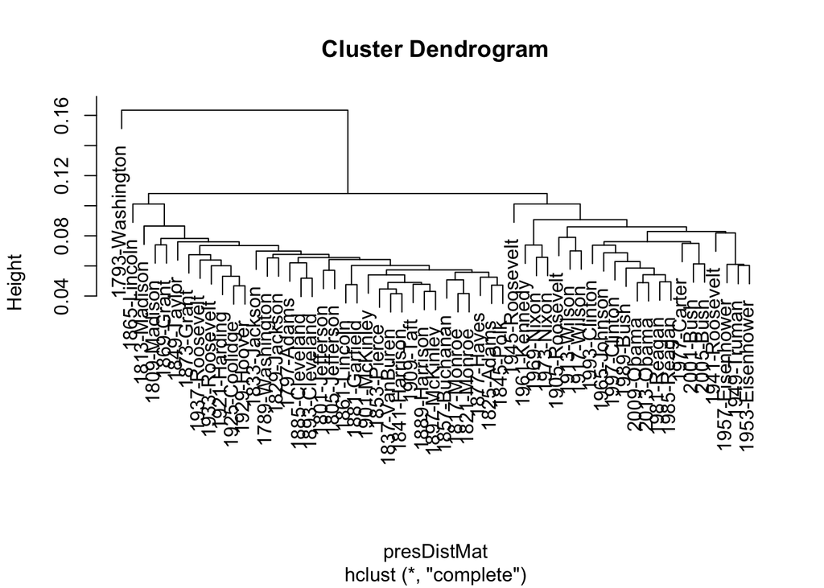

```r
# hierarchical clustering - get distances on normalized dfm
presDistMat <- dist(as.matrix(weight(presDfm, "relFreq")))
# hiarchical clustering the distance object
presCluster <- hclust(presDistMat)
# plot as a dendrogram
plot(presCluster)
```

Or to cluster terms:

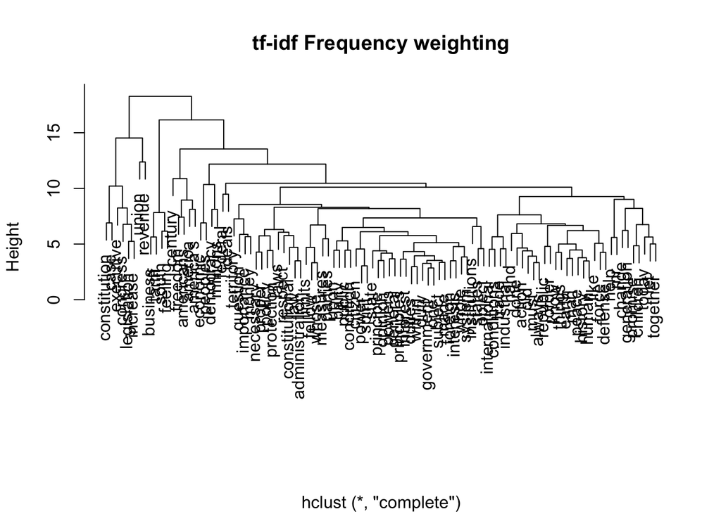

```r
# word dendrogram with tf-idf weighting
wordDfm <- sort(weight(presDfm, "tfidf"))
wordDfm <- t(wordDfm)[1:100,]  # because transposed
wordDistMat <- dist(wordDfm)
wordCluster <- hclust(wordDistMat)
plot(wordCluster, xlab="", main="tf-idf Frequency weighting")
```

We’ll see better ways to cluster documents and words in the last module of today’s workshop.